# KeplerClassification - 1

Libraries import.

```r
library(naniar)
library(tidyverse)
library(zoo)
```

We start reading the original data.

```r
data_original <- read.csv(paste0("data/cumulative.csv"))
summary(data_original)
```

```
##      rowid          kepid              kepoi_name         kepler_name
##  Min.   :   1   Min.   :  757450   K00001.01:   1               :7270
##  1st Qu.:2392   1st Qu.: 5556034   K00002.01:   1   Kepler-1 b  :   1
##  Median :4782   Median : 7906892   K00003.01:   1   Kepler-10 b :   1
##  Mean   :4782   Mean   : 7690628   K00004.01:   1   Kepler-10 c :   1
##  3rd Qu.:7173   3rd Qu.: 9873066   K00005.01:   1   Kepler-100 b:   1
##  Max.   :9564   Max.   :12935144   K00005.02:   1   Kepler-100 c:   1
##                                    (Other)  :9558   (Other)     :2289
##        koi_disposition       koi_pdisposition   koi_score      koi_fpflag_nt
##  CANDIDATE     :2248   CANDIDATE     :4496    Min.   :0.0000   Min.   :0.0000
##  CONFIRMED     :2293   FALSE POSITIVE:5068    1st Qu.:0.0000   1st Qu.:0.0000
##  FALSE POSITIVE:5023                          Median :0.3340   Median :0.0000
##                                               Mean   :0.4808   Mean   :0.1882
##                                               3rd Qu.:0.9980   3rd Qu.:0.0000
##                                               Max.   :1.0000   Max.   :1.0000
##                                               NA's   :1510
##  koi_fpflag_ss    koi_fpflag_co    koi_fpflag_ec    koi_period
##  Min.   :0.0000   Min.   :0.0000   Min.   :0.00   Min.   :     0.24
##  1st Qu.:0.0000   1st Qu.:0.0000   1st Qu.:0.00   1st Qu.:     2.73
##  Median :0.0000   Median :0.0000   Median :0.00   Median :     9.75
##  Mean   :0.2316   Mean   :0.1949   Mean   :0.12   Mean   :    75.67
##  3rd Qu.:0.0000   3rd Qu.:0.0000   3rd Qu.:0.00   3rd Qu.:    40.72
##  Max.   :1.0000   Max.   :1.0000   Max.   :1.00   Max.   :129995.78
##
##  koi_period_err1  koi_period_err2    koi_time0bk     koi_time0bk_err1
##  Min.   :0.0000   Min.   :-0.1725   Min.   : 120.5   Min.   :0.0000
##  1st Qu.:0.0000   1st Qu.:-0.0003   1st Qu.: 132.8   1st Qu.:0.0012
##  Median :0.0000   Median : 0.0000   Median : 137.2   Median :0.0041
##  Mean   :0.0021   Mean   :-0.0021   Mean   : 166.2   Mean   :0.0099
##  3rd Qu.:0.0003   3rd Qu.: 0.0000   3rd Qu.: 170.7   3rd Qu.:0.0105
##  Max.   :0.1725   Max.   : 0.0000   Max.   :1472.5   Max.   :0.5690
##  NA's   :454      NA's   :454                        NA's   :454
##  koi_time0bk_err2    koi_impact       koi_impact_err1  koi_impact_err2
##  Min.   :-0.5690   Min.   :  0.0000   Min.   : 0.000   Min.   :-59.3200
##  1st Qu.:-0.0105   1st Qu.:  0.1970   1st Qu.: 0.040   1st Qu.: -0.4450
##  Median :-0.0041   Median :  0.5370   Median : 0.193   Median : -0.2070
##  Mean   :-0.0099   Mean   :  0.7351   Mean   : 1.960   Mean   : -0.3326
##  3rd Qu.:-0.0012   3rd Qu.:  0.8890   3rd Qu.: 0.378   3rd Qu.: -0.0460
##  Max.   : 0.0000   Max.   :100.8060   Max.   :85.540   Max.   :  0.0000
##  NA's   :454       NA's   :363        NA's   :454      NA's   :454
```

[output cut: 49 more lines]

```
##  Min.   :  0.109   Min.   : 0.0000   Min.   :-116.1370   Min.   :279.9
##  1st Qu.:  0.829   1st Qu.: 0.1290   1st Qu.:  -0.2500   1st Qu.:288.7
##  Median :  1.000   Median : 0.2510   Median :  -0.1110   Median :292.3
##  Mean   :  1.729   Mean   : 0.3623   Mean   :  -0.3948   Mean   :292.1
##  3rd Qu.:  1.345   3rd Qu.: 0.3640   3rd Qu.:  -0.0690   3rd Qu.:295.9
##  Max.   :229.908   Max.   :33.0910   Max.   :   0.0000   Max.   :301.7
##  NA's   :363       NA's   :468       NA's   :468
##       dec          koi_kepmag
##  Min.   :36.58   Min.   : 6.966
##  1st Qu.:40.78   1st Qu.:13.440
##  Median :43.68   Median :14.520
##  Mean   :43.81   Mean   :14.265
##  3rd Qu.:46.71   3rd Qu.:15.322
##  Max.   :52.34   Max.   :20.003
##                  NA's   :1
```

Before going to analyze and expore the data, we can select the variables of interest in this case. In fact, several features can be considered as useless for the aim of this project, in particular: - All the errors with respect to the physical quantities. - Categorical variables not useful for our purpose.

```r
data <- data_original %>%
  select(-c(rowid, kepid, kepoi_name, kepler_name, koi_tce_delivname, koi_tce_plnt_num, ends_with("err1"), ends_with("err2")))
```

Start exploring the data

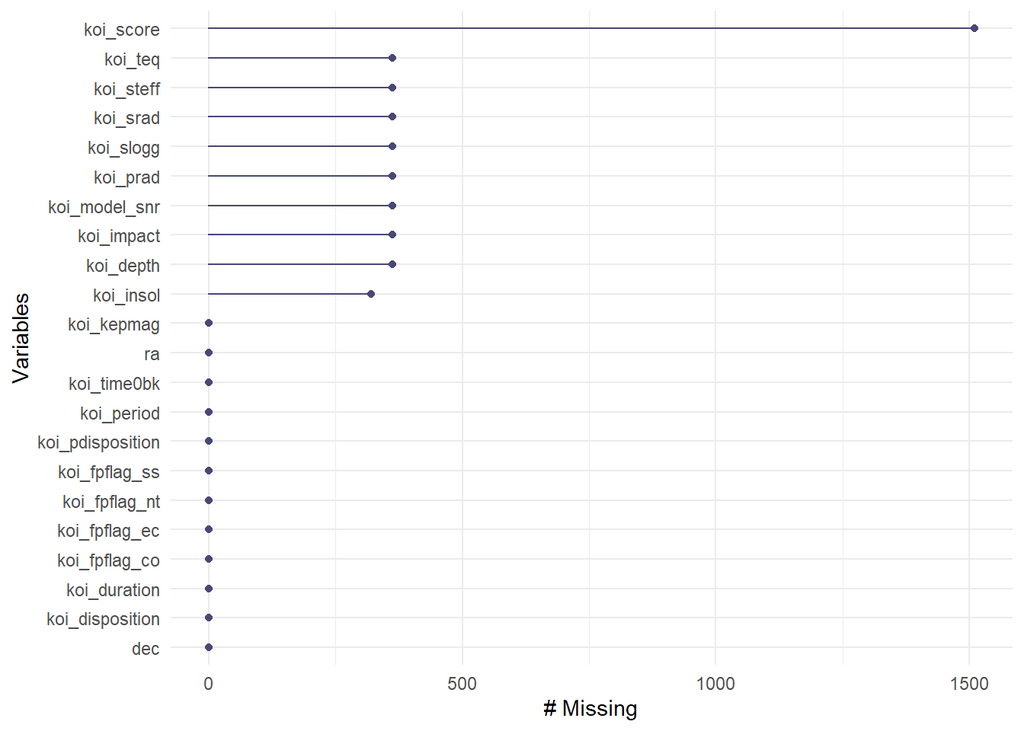

```r
gg_miss_var(data)
```

Since quite a few observations are represented as missing values for some features, we are going to eliminate them.

Removing NA observation of koi_teq, koi_kepmag

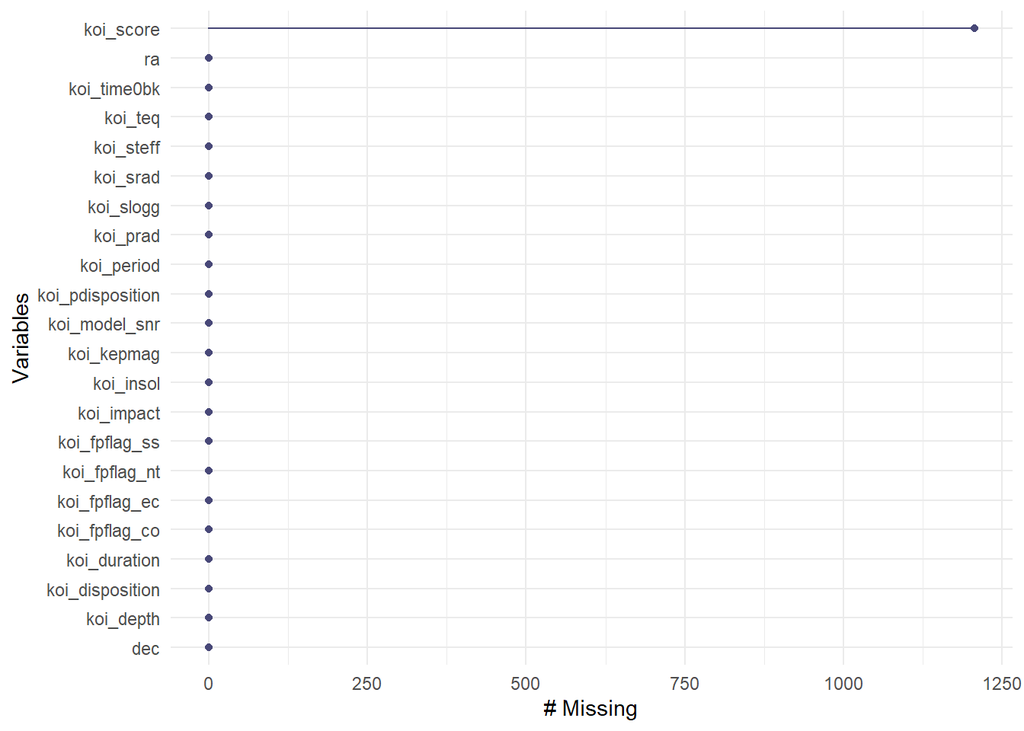

```r
data <- data %>%
    filter(!is.na(koi_teq), !is.na(koi_kepmag))

gg_miss_var(data)
```

364 observations were missing values and thus have been eliminated.

Now, only variable koi_score presents a big amount of missing values. (Roughly 15%).

We would like to handle it through 2 different methods: - Records elimination - Missing replacement by conditionated mean among the koi_disposition classes.

```r
data %>%
  filter(is.na(koi_score))
```

| koi_disposition | koi_pdisposition | koi_score | koi_fpflag_nt | koi_fpflag_ss | koi_fpflag_co | koi_fpflag_ec | koi_period | koi_time0bk | koi_impact | koi_duration | koi_depth | koi_prad | koi_teq | koi_insol | koi_model_snr | koi_steff | koi_slogg | koi_srad | ra | dec | koi_kepmag |
| --- | --- | --- | --- | --- | --- | --- | --- | --- | --- | --- | --- | --- | --- | --- | --- | --- | --- | --- | --- | --- | --- |
| FALSE POSITIVE | FALSE POSITIVE | NA | 0 | 1 | 0 | 0 | 3.866031e+02 | 166.3421 | 0.9765 | 6.80570 | 24927.0 | 41.50 | 297 | 1.84 | 994.0 | 5543 | 4.081 | 1.580 | 292.2737 | 37.67156 | 12.394 |
| FALSE POSITIVE | FALSE POSITIVE | NA | 0 | 0 | 0 | 1 | 1.417982e+01 | 171.5024 | 0.1601 | 2.50500 | 459.9 | 1.88 | 711 | 60.35 | 11.2 | 5799 | 4.539 | 0.878 | 291.0448 | 51.32167 | 15.727 |
| CONFIRMED | CANDIDATE | NA | 0 | 0 | 0 | 0 | 2.915986e+01 | 150.6992 | 0.3619 | 4.80300 | 488.0 | 1.91 | 524 | 17.85 | 11.6 | 5485 | 4.556 | 0.867 | 285.2836 | 38.94728 | 15.403 |
| CANDIDATE | CANDIDATE | NA | 0 | 0 | 0 | 0 | 1.028437e+00 | 170.2286 | 1.5734 | 1.86060 | 8098.0 | 72.77 | 1947 | 3400.48 | 89.6 | 6228 | 4.428 | 0.990 | 296.0070 | 40.29543 | 15.202 |
| CANDIDATE | CANDIDATE | NA | 0 | 0 | 0 | 0 | 8.566721e+02 | 228.4499 | 0.1158 | 23.14400 | 858.1 | 3.87 | 242 | 0.81 | 39.2 | 6449 | 4.232 | 1.309 | 287.5868 | 47.60002 | 13.997 |
| FALSE POSITIVE | FALSE POSITIVE | NA | 1 | 0 | 0 | 1 | 4.452771e-01 | 133.5231 | 1.2962 | 3.53900 | 186.7 | 35.74 | 2562 | 10177.11 | 28.9 | 6167 | 4.444 | 1.064 | 297.1035 | 47.64357 | 15.343 |
| CANDIDATE | CANDIDATE | NA | 0 | 0 | 0 | 0 | 1.299958e+05 | 393.5996 | 0.7127 | 9.40800 | 1474.9 | 2.99 | 25 | 0.00 | 35.7 | 4500 | 4.572 | 0.726 | 296.8216 | 47.35403 | 13.447 |
| FALSE POSITIVE | FALSE POSITIVE | NA | 0 | 0 | 0 | 0 | 3.997514e+00 | 261.7243 | 0.0303 | 3.68600 | 32.8 | 2.98 | 2203 | 5563.95 | 6.1 | 5066 | 3.122 | 5.324 | 283.7364 | 44.71331 | 10.733 |
| FALSE POSITIVE | FALSE POSITIVE | NA | 0 | 0 | 0 | 0 | 7.154861e+00 | 266.0485 | 0.9848 | 7.69400 | 780.4 | 7.41 | 1482 | 1141.57 | 24.2 | 7443 | 4.166 | 1.739 | 289.8741 | 49.68549 | 12.616 |
| FALSE POSITIVE | FALSE POSITIVE | NA | 0 | 0 | 0 | 0 | 3.322695e+00 | 134.4440 | 0.4722 | 3.56800 | 78.7 | 15.33 | 3859 | 52428.30 | 8.6 | 5234 | 2.410 | 16.959 | 288.6826 | 41.30732 | 11.899 |

[output cut: 1196 more lines]

koi_score NA: among candidate = 393 koi_score NA: among confirmed = 11 koi_score NA: among false positive = 802 tot: 1206.

Let’s analyze the differences between koi_disposition and koi_pdisposition:

```r
data %>%
  group_by(koi_disposition, koi_pdisposition) %>%
  summarise(tot = n())
```

| koi_disposition | koi_pdisposition | tot |
| --- | --- | --- |
| CANDIDATE | CANDIDATE | 2185 |
| CONFIRMED | CANDIDATE | 2248 |
| CONFIRMED | FALSE POSITIVE | 44 |
| FALSE POSITIVE | FALSE POSITIVE | 4723 |

We should state that: pdisposition classifies the records only as false positive or candidate based on the kepler data. Conversely, disposition refers to the Exoplanet Archive categories. Thus, only by this last variable, we can state if a koi is effectively an exoplanet or not. Moreover, we will eliminate all the missing observations (1206) for the feature koi_score. The reason lies on the fact that koi_score is thought as a value between 0 and 1, which indicates the confidence in the koi disposition. We can’t make any assumption of the confidence value, since we are not domain experts. Furthermore, almost all the NA for koi_score concerns objects that are not confirmed.

```r
data <- data %>%
  select(- koi_pdisposition) %>%
  filter(!is.na(koi_score))
```

Missing map:

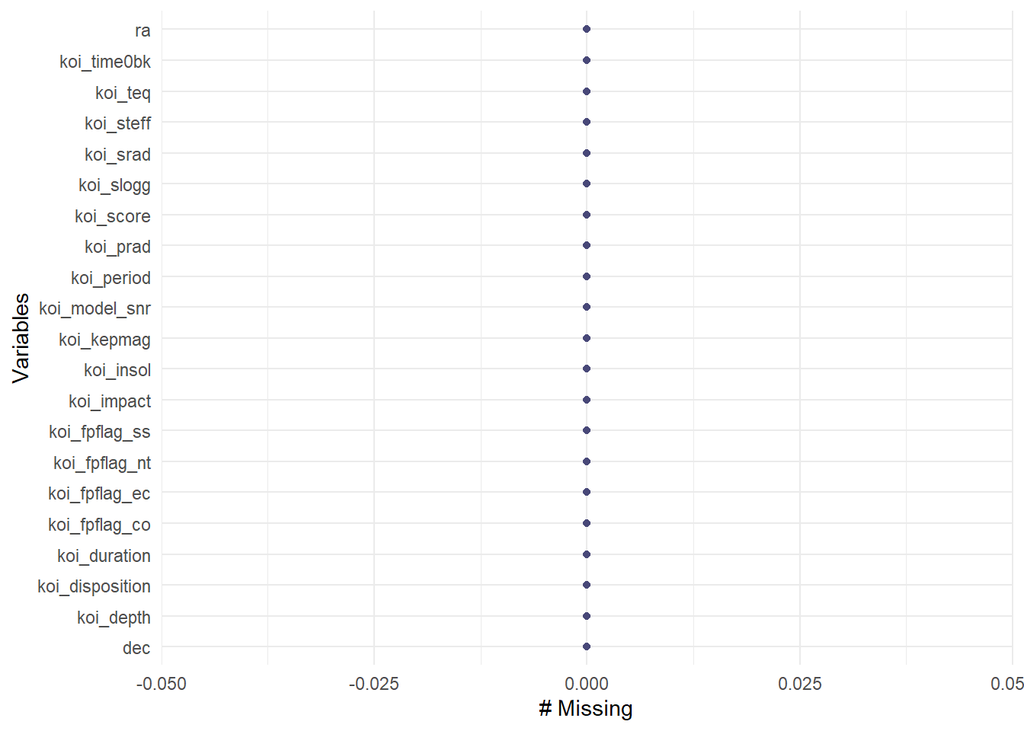

```r
gg_miss_var(data)
```

We don’t have any missing value anymore.

So, we will consider as target variable koi_disposition. Before that, we will make a binarization, considering as positive class (value 1) all the objects confirmed, while false positive and candidate will be considered as negative (value 0).

```r
data <- data %>%
  mutate(target = ifelse(koi_disposition=='CONFIRMED', 1, 0)) %>%
  select(-koi_disposition)
```

```r
#write.csv(data, paste0(data_path, "data_preprocessed.csv"))
```